# Di Zhen(1717719)

dizhen

2020-01-08

## Exercise 1.

### Step1. Data

The data comes from a study by Thienprasiddhi et al.

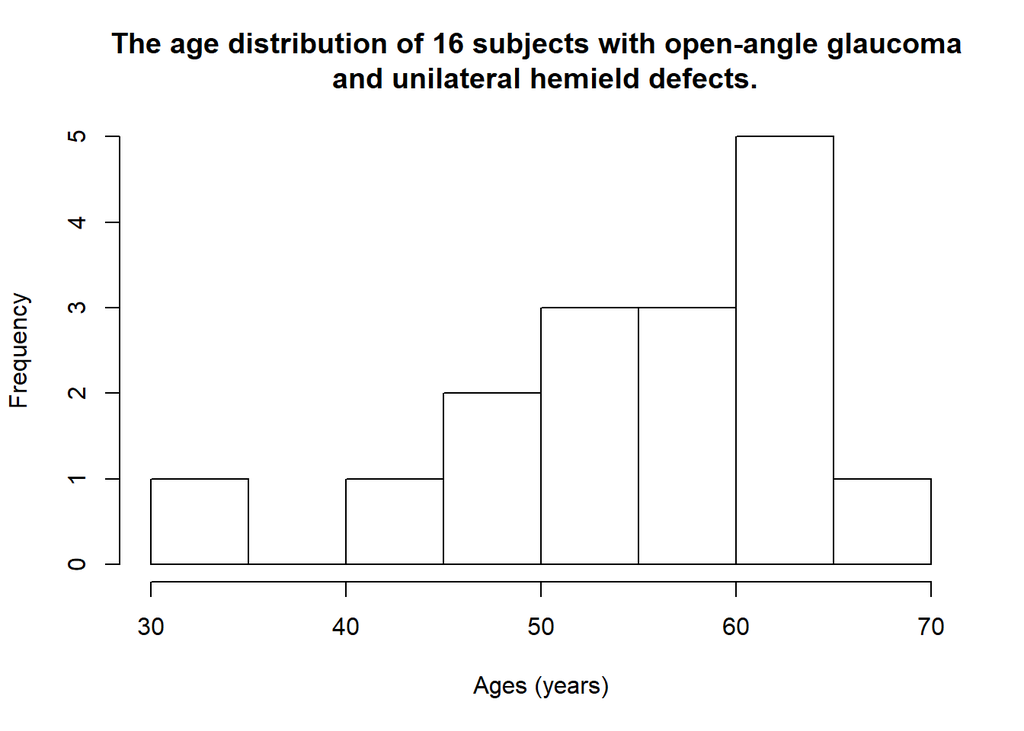

```r
ages <- c(62, 62, 68, 48, 51, 60, 51, 57, 57, 41, 62, 50, 53, 34, 62, 61)
hist(ages,
     xlab = "Ages (years)",
     main = "The age distribution of 16 subjects with open-angle glaucoma \n and unilateral hemield defects.")
```

```r
summary(ages)
```

```
##    Min. 1st Qu.  Median    Mean 3rd Qu.    Max.
##   34.00   50.75   57.00   54.94   62.00   68.00
```

### Step2. Assumptions

1.The sample is simple random sample 2.The sample size is n = 16, which does not >30. In the histogram, the data appear to be from a normally distributed population. Both requirments are satisfied.

### Step3. Hypothesis

Alternative hypothesis: the mean age $\bar{x}$ of the population is less than 60.
$$H_0: \bar{x}\geqslant60\\
H_A: \bar{x}< 60$$

### Step4. Test Statistic

As population $\sigma$ is unknown, we apply t-test.
$$t = \frac{\bar{x}-\mu}{s/\sqrt{n}}$$
$$\nu = n-1$$

### Step5. Distribution of the Test Statistic

As the sampling distribution of t is the standard normal distribution, so:
$$t \sim N(0,1)$$

### Step6. Decision Rule

This is a left-tailed test. The significant level $\alpha = 0.05$, so that critical value $t_0 = -1.75$. This determines that the critical region is the area where $t_0 < -1.75$.

```r
alpha <- 0.05
t_alpha <- qt(1 - alpha,15)
-t_alpha
```

```
## [1] -1.75305
```

### Step7. Calculation of test statistic

$$t = \frac{\bar{x}-\mu}{s/\sqrt{n}} = \frac{54.9-60}{8.8/\sqrt{16}} = -2.282$$
This consists of calculation in step4 and the result $t = -2.282$ is compared to the critical value calculated in step6. t value = -2.282 is less than critical value $t_0 = -1.75$.

```r
ages_bar <- mean(ages)
ages_n <- length(ages)
ages_mu0 <- 60
ages_sd <- sd(ages)
ages_t <- sqrt(ages_n)*(ages_bar-ages_mu0)/ages_sd
ages_t
```

```
## [1] -2.282218
```

### Step8. Statistical decision

Since the t value falls in the rejection region, we rejected null hypothesis.

### Step9. Conclusion

As we reject the null hypothesis, we can conclude that the mean age $\bar{x}$ of the population from which the sample may be presumed to have been drawn is significantly less (t = -2.282, df = 15, p-value = 0.019) than 60.

### Step10. P-value

```r
p_value = pt(-abs(ages_t),df=15)
p_value
```

```
## [1] 0.01874476
```

p-value is 0.019. 1. If the study is repeated many times, there is 1.9% chance of observing the mean age $\bar{x}$ of the population is less than 60. 2. There is a 1.9% chance that observing a same age in our samples or even less age.

```r
t.test(ages,
       mu = 60,
       alternative = c("less"),
       conf.level = 0.95)
```

```
##
##  One Sample t-test
##
## data:  ages
## t = -2.2822, df = 15, p-value = 0.01874
## alternative hypothesis: true mean is less than 60
## 95 percent confidence interval:
##      -Inf 58.82618
## sample estimates:
## mean of x
##   54.9375
```

## Exercise 2.

### Step1. Data

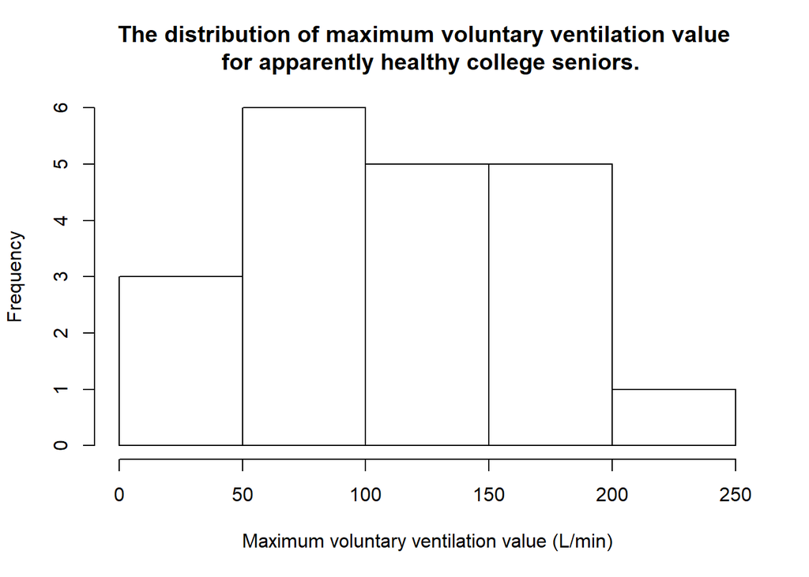

```r
vent <- c(132, 33, 91, 108, 67, 169, 54, 203, 190, 133, 96, 30, 187, 21, 63, 166, 84, 110, 157, 138)
hist(vent,
     xlab = "Maximum voluntary ventilation value (L/min)",
     main = "The distribution of maximum voluntary ventilation value \n for apparently healthy college seniors.")
```

```r
summary(vent)
```

```
##    Min. 1st Qu.  Median    Mean 3rd Qu.    Max.
##    21.0    66.0   109.0   111.6   159.2   203.0
```

### Step2. Assumptions

1.The sample is simple random sample. 2.The sample size is n = 20, which does not >30. In the histogram, the data appear to be from a normally distributed population. Both requirments are satisfied.

### Step4. Test Statistic

As population $\sigma$ is unknown, we use t-test.
$$t = \frac{\bar{x}-\mu}{s/\sqrt{n}}$$
$$\nu = n-1$$

### Step5. Distribution of the Test Statistic

As the sampling distribution of t is the standard normal distribution, so:
$$t \sim N(0,1)$$

### Step6. Decision Rule

```r
alpha1 <- 0.01
t_alpha1 <- qt(1 - alpha1/2, 19)
-t_alpha1
```

```
## [1] -2.860935
```

### Step7. Calculation of test statistic

$$t = \frac{\bar{x}-\mu}{s/\sqrt{n}} = \frac{111.6-110}{56.3/\sqrt{20}} = 0.127$$
This consists of calculation in step4 and the result $t = 0.127$ is compared to the critical value calculated in step6. t value 0.127 falls between $t_0 = 2.86$ and $-t_0 = -2.86$.

```r
vent_bar <- mean(vent)
vent_n <- length(vent)
vent_mu0 <- 110
vent_sd <- sd(vent)
vent_t <- sqrt(vent_n)*(vent_bar-vent_mu0)/vent_sd
vent_t
```

```
## [1] 0.1270874
```

### Step8. Statistical decision

Since the t value does not fall in the rejection region, we fail to reject null hypothesis.

### Step9. Conclusion

As we fail to reject null hypothesis, We can conclude that mean maximum voluntary ventilation value $\bar{x}$ for apparently healthy college seniors has not found to differ significantly (t = 0.127, df = 19, p-value = 0.900) with 110 liters per minute.

### Step10. P-value

1. If the study is repeated many times, there is 90% chance that the mean maximum voluntary ventilation value $\bar{x}$ of the population is different or more different than 110 liters per minute.
2. There is a 90% chance of observing a difference as large or larger than observed.

```r
t.test(vent,
       mu = 110,
       alternative = c("two.sided"),
       conf.level = 0.99)
```

```
##
##  One Sample t-test
##
## data:  vent
## t = 0.12709, df = 19, p-value = 0.9002
## alternative hypothesis: true mean is not equal to 110
## 99 percent confidence interval:
##   75.58151 147.61849
## sample estimates:
## mean of x
##     111.6
```

Q: What assumptions are necessary? A: Assume the data were randomly sampled and voluntary ventilation value of population are normally distributed.